# TRABAJO Nº3 - GRUPO 4

## Pregunta 3

Analizar los distintos tipos de peticiones HTTP (GET, POST, PUT, DELETE) gestionadas por el servidor, identificando la frecuencia de cada una de estas. Repetir el análisis, esta vez filtrando previamente aquellas peticiones correspondientes a recursos ofrecidos de tipo imagen.

```r
epa_http <- epa_http %>%
  mutate(
    is_image = case_when(
      stringr::str_detect(uri, "(?i)\\.(jpg|jpeg|png|xbm|svg|gif|tiff|psd|bmp|eps|ps)$") ~ TRUE,
      TRUE ~ FALSE
    )
  )
p2_df <- epa_http %>% group_by(metodoHttp,is_image) %>% summarise(peticiones  = n())
p2_df
```

```
## # A tibble: 6 × 3
## # Groups:   metodoHttp [3]
##   metodoHttp is_image peticiones
##   <chr>      <lgl>         <int>
## 1 GET        FALSE         22982
## 2 GET        TRUE          23038
## 3 HEAD       FALSE            49
## 4 HEAD       TRUE             57
## 5 POST       FALSE          1355
## 6 POST       TRUE            267
```

## Pregunta 4

Utilizando un algoritmo de aprendizaje no supervisado, realizad un análisis de clústering con k-means para los datos del servidor.

```r
epa_http$exitoso <-factor(epa_http$exitoso)
epa_http$is_image <-factor(epa_http$is_image)
epa_http$metodoHttp<- factor(epa_http$metodoHttp)
epa_http$protocolo<- factor(epa_http$protocolo)

epa_http$num_letras <- nchar(epa_http$uri)
epa_http$num_letras <- NULL


epa_http_one_hot <- one_hot(as.data.table(epa_http), sparsifyNAs = TRUE)


columnas_a_mantener <- c("metodoHttp", "protocolo", "respuestaHttp","bytes","exitoso","is_image")
epa_http_new <- epa_http[, columnas_a_mantener, drop = FALSE]

epa_http_one_hot <- one_hot(as.data.table(epa_http_new), sparsifyNAs = TRUE)

names(epa_http_one_hot)
```

```
##  [1] "metodoHttp_GET"     "metodoHttp_HEAD"    "metodoHttp_POST"
##  [4] "protocolo_HTTP/0.2" "protocolo_HTTP/1.0" "respuestaHttp"
##  [7] "bytes"              "exitoso_FALSE"      "exitoso_TRUE"
## [10] "is_image_FALSE"     "is_image_TRUE"
```

```r
set.seed(1234)
kmeans1 <- kmeans(epa_http_one_hot, 3, iter.max = 100, nstart = 1)
kmeans2 <- kmeans(epa_http_one_hot, 7, iter.max = 100, nstart = 1)
#printing
kmeans1
```

```
## K-means clustering with 3 clusters of sizes 47566, 130, 52
##
## Cluster means:
##   metodoHttp_GET metodoHttp_HEAD metodoHttp_POST protocolo_HTTP/0.2
## 1      0.9637346     0.002228483      0.03403692       2.102342e-05
## 2      0.9769231     0.000000000      0.02307692       0.000000e+00
## 3      1.0000000     0.000000000      0.00000000       0.000000e+00
##   protocolo_HTTP/1.0 respuestaHttp       bytes exitoso_FALSE exitoso_TRUE
## 1           0.999979      227.2136    3817.895    0.02585881    0.9741412
## 2           1.000000      200.0000  370692.323    0.00000000    1.0000000
## 3           1.000000      200.0000 1578307.769    0.00000000    1.0000000
##   is_image_FALSE is_image_TRUE
## 1      0.5089770    0.49102300
## 2      0.9538462    0.04615385
## 3      1.0000000    0.00000000
```

[output cut: 1338 more lines]

```r
kmeans2
```

```
## K-means clustering with 7 clusters of sizes 114, 44523, 11, 519, 43, 38, 2500
##
## Cluster means:
##   metodoHttp_GET metodoHttp_HEAD metodoHttp_POST protocolo_HTTP/0.2
## 1      0.9912281     0.000000000     0.008771930        0.00000e+00
## 2      0.9756755     0.002380792     0.021943714        2.24603e-05
## 3      1.0000000     0.000000000     0.000000000        0.00000e+00
## 4      0.9961464     0.000000000     0.003853565        0.00000e+00
## 5      1.0000000     0.000000000     0.000000000        0.00000e+00
## 6      0.9473684     0.000000000     0.052631579        0.00000e+00
## 7      0.7440000     0.000000000     0.256000000        0.00000e+00
##   protocolo_HTTP/1.0 respuestaHttp       bytes exitoso_FALSE exitoso_TRUE
## 1          1.0000000      200.0000  249236.368    0.00000000    1.0000000
## 2          0.9999775      229.0736    1666.282    0.02762617    0.9723738
## 3          1.0000000      200.0000 2807039.364    0.00000000    1.0000000
```

[output cut: 1351 more lines]

## Pregunta 7

Representad visualmente en gráficos de tipo scatter plot el resultado de vuestros clústering y interpretad el resultado obtenido (describid las características de los distintos grupos) con los 2 valores distintos de k probados en el apartado anterior en función de los valores de las variables y el número de clúster asignado.

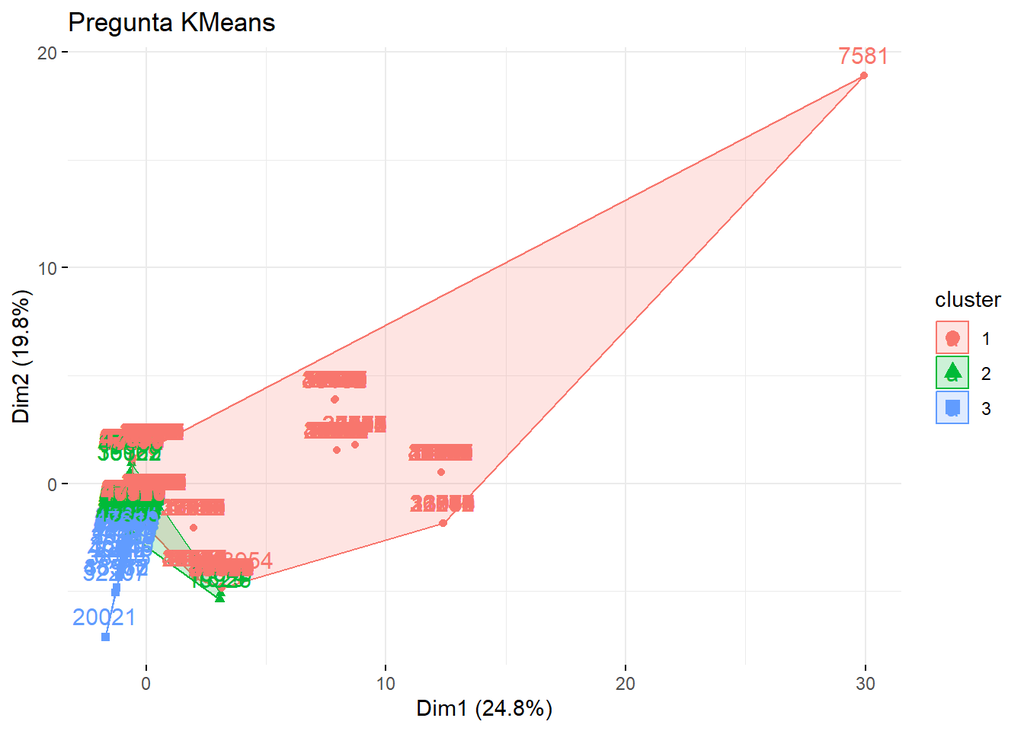

```r
fviz_cluster(kmeans1, data = epa_http_one_hot,ggtheme = theme_minimal(),show.clust.cent = TRUE,
            main = "Pregunta KMeans",
             ellipse = TRUE,
             #axes = c(6, 10),
             axes = c(1, 2),
             ellipse.type = "convex",
             ellipse.level = 0.95,
             ellipse.alpha = 0.2)
```

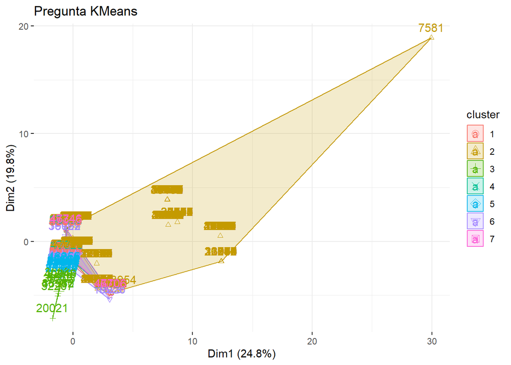

```r
fviz_cluster(kmeans2, data = epa_http_one_hot,ggtheme = theme_minimal(),show.clust.cent = TRUE,
             main = "Pregunta KMeans",
             ellipse = TRUE,
             #axes = c(6, 10),
             axes = c(1, 2),
             ellipse.type = "convex",
             ellipse.level = 0.95,
             ellipse.alpha = 0.2)
```